# UNICEF Data Analysis: A Global Perspective

# 6 Scattereplot with Regression Line

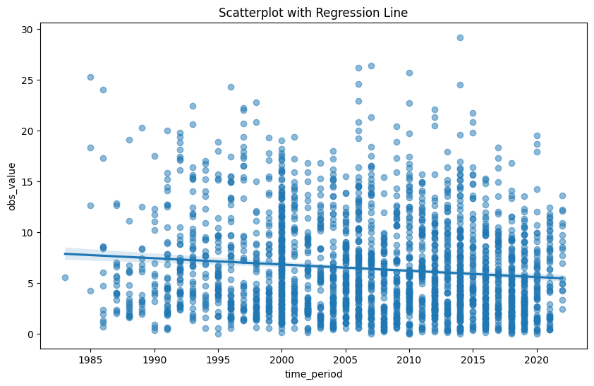

```python
# @title Default title text
# Scattereplot
df['time_period'] = pd.to_numeric(df['time_period'], errors='coerce')

plt.figure(figsize=(10, 6))
sns.regplot(x="time_period", y="obs_value", data=df, scatter_kws={"alpha": 0.5})
plt.title("Scatterplot with Regression Line")
plt.show()
```

# 7 Pakistan Time Series Graph

The line chart shows the trend of observed values obs_value in Pakistan throughout specific time intervals. A shaded region surrounds the line to display the confidence interval which reflects the level of estimation uncertainty.

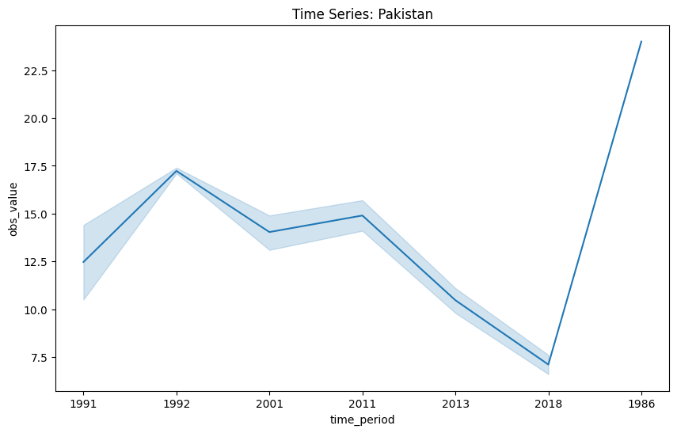

```python
# @title Default title text
# Time Series Graph
country = 'Pakistan'
df_country = df[df['country'] == country]

plt.figure(figsize=(10,6))
sns.lineplot(data=df_country, x='time_period', y='obs_value')
plt.title(f'Time Series: {country}')
plt.xlabel('time_period')
plt.ylabel('obs_value')
plt.show()
```

# 8 Global Observation Rate

The map displays global observation rates (%) according to UNICEF data by showing the percentage of collected observations from countries. The observation frequency scale in this map uses light colors to represent high rates but dark colors indicate low observations. The representation assists in revealing areas where child welfare data collection exceeds other regions for five-year-old children.

```python
# @title Default title text
!pip install geopandas matplotlib plotnine
```

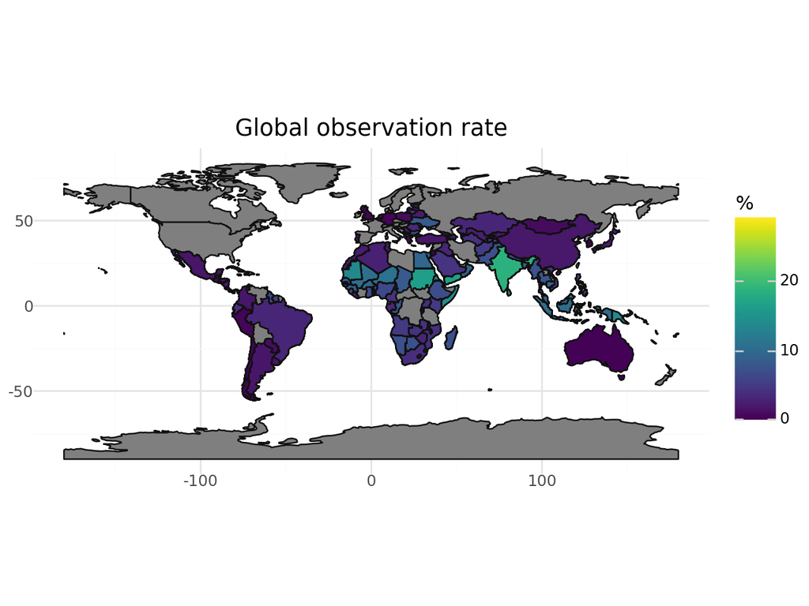

```python
# @title Default title text
import geopandas as gpd
import matplotlib.pyplot as plt
from plotnine import *

df = pd.read_csv("unicef_indicator_1 (1).csv")
df.head()


# World Map
(
    ggplot(map_data) +
    geom_map(aes(fill='obs_value', map_id='country')) +
    coord_equal() +
    theme_minimal() +
    labs(
        title="Global observation rate",
        fill="%"
    )
)
```

# 9 *CONCLUSION*

The research used UNICEF data to study child welfare trends for children less than five years old yet it demonstrated variations across different countries and time periods.

Future studies need to analyze single-country statistics to extend their analysis using global data sources.